# What a Voter File Records, and Why

The only instrument that can tell you whether a survey is lying

Democracy’s Data

Last updated September 13, 2026 at 10:53a EDT

The surveys chapter asks people questions. The census chapter counts everyone. This one is about a source that does neither, and was not built for us at all.

A voter file — the state’s list of everyone registered to vote, one row per registration — exists so that a poll worker can decide whether the person standing in front of them may vote today. That is its entire job. It is an **operational record**, kept under legal obligation by an election office. Every research use of it, including every use in this book, is a borrowing. Nothing about its design anticipated anyone studying it.

Which turns out to be its great advantage. Because it was not built to answer questions, it has no stake in the answers.

## Where the data comes from, and what it is for

A voter file is kept by the election office of a state or county, because federal law says it must be. The Help America Vote Act of 2002 (HAVA), the federal law written after the disputed Florida count of 2000, required every state to maintain a single statewide computerised registration list, which is why a modern voter file exists at all.[^1] What goes into the list, and what its columns are called, was left entirely to the states.

**Who is in it, and how they got there.** People who performed an administrative act: registering to vote. One row is one registration, not one adult and not one eligible citizen. Everyone who never registered is absent, and absent in a patterned way rather than a random one. That matters most when the file is used as a denominator, the bottom number of a rate. Turnout “among registered voters” is always higher than turnout “among eligible adults”, because registering is itself a filter for the kind of person who votes.

**Who it was made for.** The poll worker, and the office behind them. Read the columns as a job description and every one of them is doing the same job — get one person to the right ballot, once.

Name and address establish who you are and where you live. Precinct and district columns say which of a county’s many ballot styles is yours. Party decides which primary — the election a party holds to choose its own candidates — you may vote in. Status says whether you may vote today without further paperwork. The **voter history** file, the state’s separate record of which elections each registrant took part in, records *that* you voted, never how, because the office must be able to show that nobody voted twice. There is no opinion column, because no ballot depends on your opinions.

**What it costs to get.** More than the law suggests. The file is a public record in every state and downloadable in almost none of them; you may be asked to sign something, pay something, or appear somewhere in person. *Public* and *obtainable* are different words, and the voter-file-access brief measures the gap between them across all fifty-one jurisdictions. The two files this chapter reads, Georgia’s and New Jersey’s, were obtained as working data for a redistricting matter and are not redistributed here. A reader who wants them starts where anyone does: Georgia sells its statewide list to whoever orders it, through the Secretary of State’s page at https://sos.ga.gov/page/order-voter-registration-lists-and-files, and New Jersey’s Division of Elections releases its list on request.

**What has already been done to it.** Maintenance, continuously. Election offices match the list against change-of-address data, mark registrants inactive when mail comes back, and remove people under the rules the National Voter Registration Act of 1993 (NVRA, the “motor voter” law) sets for **list maintenance** — the routine removal of the dead and the moved, which the law calls maintenance and its critics call purging.[^2] The file you receive is a snapshot of the moment it was extracted, already reshaped by every removal that came before. This chapter measures what that does to the past.

## Fifty states, fifty files

There is no national voter file. HAVA required a statewide list; it required nothing whatever about what the list should contain, or what the columns should be called. Here is what two states’ extracts actually look like when they arrive.

```
There is no national voter file. HAVA required every state to build a
single statewide list; it required nothing about what the list should
look like. Here are the column names of two states' extracts, exactly
as they arrive.

GEORGIA -- 53 columns

County | Voter Registration Number | Status | Status Reason | Last
Name | First Name | Middle Name | Suffix | Birth Year | Residence
Street Number | Residence Pre Direction | Residence Street Name |
Residence Street Type | Residence Post Direction | Residence Apt
Unit Number | Residence City | Residence Zipcode | County Precinct
| County Precinct Description | Municipal Precinct | Municipal
Precinct Description | Congressional District | State Senate
District | State House District | Judicial District | County
Commission District | School Board District | City Council District
| Municipal School Board District | Water Board District | Super
Council District | Super Commissioner District | Super School Board
District | Fire District | Municipality | Combo | Land Lot | Land
District | Registration Date | Race | Gender | Last Modified Date |
Date of Last Contact | Last Party Voted | Last Vote Date | Voter
Created Date | Mailing Street Number | Mailing Street Name |
Mailing Apt Unit Number | Mailing City | Mailing Zipcode | Mailing
State | Mailing Country

NEW JERSEY -- 28 columns

displayId | leg_id | party | status | reg_date | last | first |
middle | suffix | dob | street_num | street_pre | street_post |
street_base | street_suff | street_name | apt_unit | city | zip |
county | municipality | ward | district | congressional |
legislative | freeholder | school | fire

Four names are shared if you ignore capitalisation -- county, municipality, status, suffix --
and none are shared if you do not. Georgia capitalises its headers
and New Jersey does not, so a join written the obvious way matches
nothing at all and reports no error while doing it.

Georgia records race and a birth YEAR; New Jersey records neither race
nor a birth year, but a full date of birth. A national file is fifty
parsing problems before it is one dataset -- and which variables you
may study at all depends on which state you are standing in.
```

| Does the file record | Georgia | New Jersey |
| --- | --- | --- |
| Name | yes | yes |
| Residence address | yes | yes |
| Mailing address | yes | no |
| Party | yes | yes |
| Race | yes | no |
| Birth year | yes | no |
| Full date of birth | no | yes |
| Registration date | yes | yes |
| Status (active or inactive) | yes | yes |
| Precinct | yes | yes |
| Congressional district | yes | yes |

Georgia’s extract has 53 columns and New Jersey’s has 28. Georgia records **race**, which most states do not, and which is why the RPV chapter, on racially polarized voting, and the BISG chapter, which tests a method for guessing race from surname and address, are possible at all. New Jersey records a **full date of birth** where Georgia records only a birth year, which is why the false-matches brief uses New Jersey.

The consequence is not merely inconvenience. **Which questions you may ask depends on which state you are standing in.** A study of racial turnout disparity is straightforward in Georgia and impossible in New Jersey from the file alone. Not because the thing being studied differs, but because one legislature decided to record a column and another did not.

## The thing only this instrument can do

Ask Americans whether they voted and they will tell you: the American National Election Studies (ANES), the academic survey that has put the question to a national sample after every presidential election since 1948, records what they said. Ask a state and it will look it up.

| Election | Registrants in the file | Recorded as voting | Share of the file |
| --- | --- | --- | --- |
| 2020 general | 127,560 | 60,591 | 47.5% |
| 2022 general | 127,560 | 53,603 | 42.0% |
| 2024 general | 127,560 | 78,334 | 61.4% |

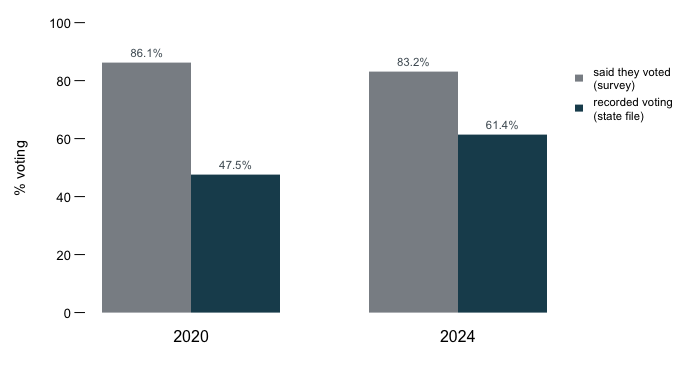

**Figure 1. What people say against what the record shows.** The grey bars are the share of ANES respondents who said they voted; the teal bars are the share of one Georgia county’s current registrants recorded as having voted. Grouped bars fit this comparison because the question is a pairwise one (the same election, measured by two instruments), and the gap to read is the gap between adjacent bars. Hover a bar for its denominator, the bottom number its share is computed against.

In the most recent study **83.2% of survey respondents said they voted**. In Houston County, Georgia, **61.4% of the 127,560 people currently registered are recorded as having voted** in the same election.

**A caution, because this comparison is easy to overstate.** These are different denominators over different populations: a national sample of adults, against the current registrants of one Georgia county. Registrants are more likely to vote than adults in general. The gap here is not a clean measure of overreporting.

But notice what the comparison establishes anyway, which is the point of the chapter. Survey turnout is *unfalsifiable from inside the survey*. A respondent who says they voted produces a data point that no other column can contradict. Surveys do overstate turnout, consistently, in every study that has checked.[^3]

The only way anyone knows that is that somebody went to an administrative record and looked the respondents up. **The voter file is the answer key.** It is the reason we know self-reports need correcting at all.

## A snapshot of administration, not a description of an electorate

The file describes the current state of an office’s paperwork, not a population. Two measurements make the difference concrete.

### The file has no past tense

| Election | Voted then and gone now | Share of everyone who voted |
| --- | --- | --- |
| 2020 general | 13,803 | 18.6% |
| 2022 general | 5,677 | 9.6% |
| 2024 general | 3,798 | 4.6% |

The arithmetic is short. The state’s history file names 74,394 Houston County voters in the 2020 general election. Look each of them up in the county’s 2026 registration file and 60,591 are there. **The other 13,803 are recorded as voting in 2020 and are no longer in the file** — 18.6% of everyone who voted. They moved, died, or were removed through list maintenance. Their votes were real and are now invisible to anyone holding only the current extract.

So the 47.5% in the table above is not the 2020 turnout rate of Houston County. It is the share of *today’s* registrants who are recorded as having voted in 2020, computed on a denominator that has been reshaped by six years of arrivals and removals. The further back you reach with a current file, the more wrong the answer, and nothing in the file warns you. A file with no past tense cannot be asked about the past, and the voter-files brief is what happens when you try.

### The state decides who counts as on it

| Status | Reason | Registrations |
| --- | --- | --- |
| ACTIVE | — | 118,174 |
| INACTIVE | NO CONTACT | 3,029 |
| INACTIVE | NCOA | 2,654 |
| INACTIVE | CROSS STATE | 2,322 |
| INACTIVE | RETURNED MAIL | 1,381 |

118,174 registrations are **active** and 9,386 are **inactive**, which is a legal status rather than a description of a person. An inactive registrant may still vote; the label records that mail was returned, or a change-of-address was matched, or a state believes they may have moved.

Whether to include them is a decision, and it changes every rate computed from the file. Include them and turnout falls; exclude them and it rises. A state that removes 200,000 inactive registrations raises its published turnout rate without a single additional person voting. The National Voter Registration Act governs how people move between these categories and when they may finally be removed: a registrant who does not answer a mailed confirmation notice, and then does not vote in the next two federal general elections, may be struck from the list — but may not be struck for not voting alone.[^4] So the denominator of a great many published numbers is set by a federal statute about list maintenance, and almost nobody who quotes those numbers knows it.

## What this data cannot tell you

The recorded-turnout figures are one county in one state. Houston County is not Georgia and Georgia is not the country; states differ in registration rules, in list-maintenance practice, and in how faithfully history files are kept. The *shape* of the lesson travels. The numbers do not.

**Nothing here measures overreporting properly.** Doing that requires matching individual survey respondents to individual records — which is exactly what the validated-turnout studies do, and what the validated-turnout brief is about. Figure 1 sets two different quantities beside each other to make a point about which one is checkable, and it should not be read as an estimate of how much people exaggerate.

**It cannot tell you why anyone voted, or what they believed.** The file records administrative acts. Opinion is Section II’s territory, and no column here holds any.

**It also says nothing about accuracy *within* the file.** Records are duplicated, names are misspelled, addresses go stale, and matching people across states is the subject of its own brief for good reason. A record kept for another purpose is kept to that purpose’s standard, not to yours.

Finally, a word about what these files are. They are public records, Georgia’s and New Jersey’s alike, and this book shows real rows from them. A chapter that showed a scrubbed imitation would teach students that the file is more private than it is. That publicness is a policy choice, made by legislatures, and it is the reason both the false-matches brief’s subject and this chapter’s evidence exist.

## What you should have learned

- A voter file is machinery for running an election. Every column exists to send one person to the right ballot, and every research use of it is a borrowing.
- Only a record can check a survey: 83.2% of ANES respondents said they voted in 2024, 61.4% of one county’s 127,560 registrants are recorded as voting, and only the second number can be verified at all.
- The file is a snapshot of administration: 13,803 people who voted in 2020, 18.6% of everyone who did, have since left the file that would be used to study them.
- There is no national voter file. Georgia’s extract carries 53 columns and New Jersey’s 28, so which questions you can ask depends on which state you are standing in.
- Active and inactive are legal statuses, not descriptions of people: 9,386 of the county’s registrations are inactive, and whether you count them changes every rate computed from the file.

## Where this data appears in this book

This chapter leads cluster III.3. Five briefs then work on the file, and each one is an operation the file’s own purpose invites — getting it, maintaining it, matching it, and mobilising the people in it:

- `voter-file-access` — public by law in fifty-one jurisdictions, downloadable in one, and what stands in between.
- `voter-files` — reading one county’s registration file, and the codes that decide which ballot you are handed.
- `false-matches` — name-and-birthdate matching in voter purges, and two strangers who share a match key.
- `disenfranchisement` — the people a felony conviction keeps off the list, state by state.
- `gotv` — what it costs to produce one additional vote, from experiments run against the file.

## Sources

- Georgia Secretary of State. Houston County voter registration extract 71754, and the statewide voter history files. Public records, obtained for the 2026 Houston County redistricting matter. Not redistributed here. The state sells its lists to anyone who orders them, at https://sos.ga.gov/page/order-voter-registration-lists-and-files, and posts its voter history files at https://mvp.sos.ga.gov/s/voter-history-files.
- New Jersey Division of Elections. Statewide voter list, 21 county extracts. Public records, released on request. Not redistributed here. https://www.nj.gov/state/elections/index.shtml
- American National Election Studies. *ANES Time Series Cumulative Data File (1948–2024)*, version of 5 February 2026, for self-reported turnout. Free, and downloadable after registering an account. https://electionstudies.org/data-center/anes-time-series-cumulative-data-file/
- Help America Vote Act of 2002, Pub. L. 107–252, §303 (statewide voter registration lists), codified at 52 U.S.C. §21083. https://www.law.cornell.edu/uscode/text/52/21083
- National Voter Registration Act of 1993, 52 U.S.C. §20507 (list maintenance). https://www.law.cornell.edu/uscode/text/52/20507
- Ansolabehere, Stephen and Eitan Hersh (2012). “Validation: What Big Data Reveal About Survey Misreporting and the Real Electorate.” *Political Analysis* 20(4): 437–459. https://doi.org/10.1093/pan/mps023

**The data itself**

Every figure above is drawn from these tables. They are plain CSV, they open in a spreadsheet, and they are yours to take further.

`attrition.csv`, `schemas.csv`, `selfreport.csv`, `status.csv`, `validated.csv`

**Your turn**

None of these is answered above, and every one can be answered from the tables you just opened.

- `selfreport.csv` and `validated.csv` measure the same election two ways, in `pct_said_they_voted` and `pct_of_current_file`. Compute both rates for each election. How large is the gap between what people say and what is recorded?
- `attrition.csv` gives `pct_of_recorded` for voters who have since left the file. Work out what a validated turnout study loses by starting from a current file, election by election.
- `schemas.csv` puts two states’ extracts side by side in the `georgia` and `new_jersey` columns. Find what one state records and the other does not. What question can you ask in one state and not the other?
- `status.csv` counts registrations by `status` and `reason`. Decide which statuses belong in a denominator for turnout, and write down the rule you would apply to all fifty states.
[^1]: 52 U.S.C. §21083, text at https://www.law.cornell.edu/uscode/text/52/21083.
[^2]: 52 U.S.C. §20507, text at https://www.law.cornell.edu/uscode/text/52/20507.
[^3]: The largest such check matched survey respondents to a national voter file and found that a substantial share of those who said they had voted had not: Stephen Ansolabehere and Eitan Hersh, “Validation: What Big Data Reveal About Survey Misreporting and the Real Electorate,” *Political Analysis* 20, no. 4 (2012): 437–459, https://doi.org/10.1093/pan/mps023.
[^4]: 52 U.S.C. §20507(b)(2) and (d), https://www.law.cornell.edu/uscode/text/52/20507; the National Conference of State Legislatures summarises how each state applies it at https://www.ncsl.org/elections-and-campaigns/voter-registration-list-maintenance.